# Monitoring Right-Wing Extremism (RWE)

Discourse, Protest, Violence

[Dr. Michael C. Zeller](https://michaelzeller.de)

**discourses** frame issues, providing basis for connection and mobilisation of collective action

**protest** is a prominent method of attempting to set political agendas and advance (movement) goals

**violence** is a common outgrowth of extremist discourse and collective action—presenting a challenge to societies and a public policy concern for state actors

## Complications of monitoring RWE

- fuzzy boundaries of ‘extremism’
- different degrees of activity in different contexts—but also different national reporting and monitoring standards
  - e.g., [RTV](https://www.sv.uio.no/c-rex/english/resources/rtv-dataset/) difficulty tracking violence beyond Western Europe; [OSCE hate crime](https://hatecrime.osce.org/) monitoring
- sensitivities about historical memory issues, involvement/complicity of political parties, timing of monitoring and public communication thereof

# RWE Discourse

- large overlap between different ‘**far-right**’ discources (Ahmed and Pisoiu 2021)
  - broadly, RW ‘extremism’ *rejects democratic principles*
- (online) discourses motivate (offline) activity and violence (Bailard et al. 2024; Giugni et al. 2005; Johnson et al. 2019; Kasimov 2023)

> intensifying expressions of grievances online predict participation in offline violence (Bailard et al. 2024)
- discursive activity can also contribute to normalising radical/extreme actors in politics and public life (Völker and Saldivia Gonzatti 2024)

## Common topics across contexts

- constantly shifting, but in recent years frequently:

climate, COVID-19, EU, gender, migration, terrorism, Ukraine

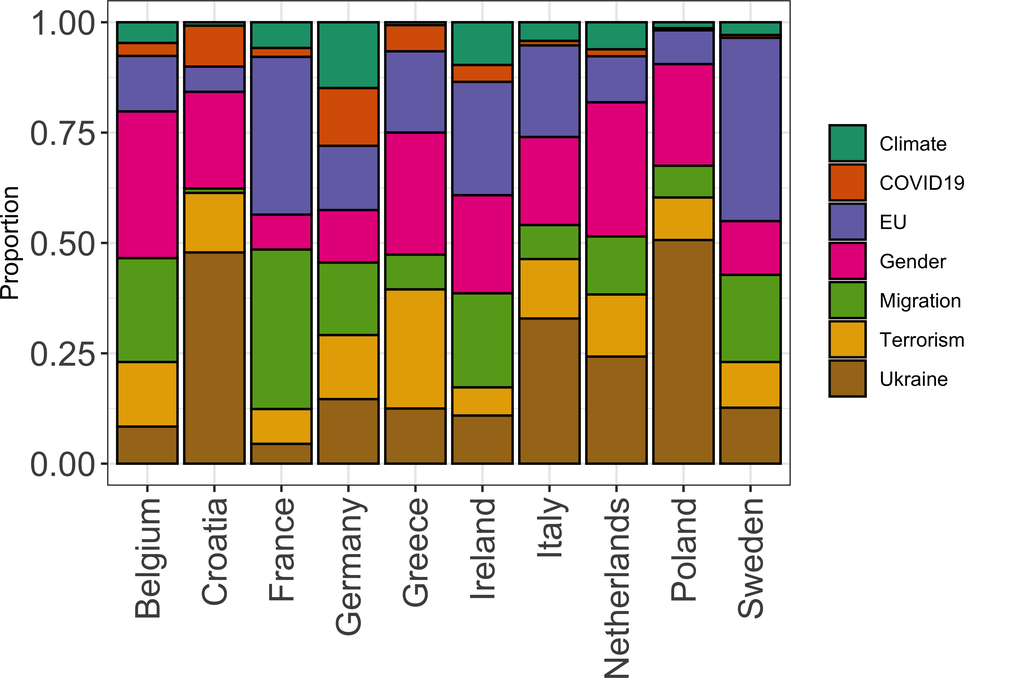

Proportion of Facebook posts about these topics by RWE groups from these countries (2021-2024)

## Gender in focus (Tronina 2026)

- common *discourses* can drive activism in different contexts
- transnational set of SMOs campaigning against ‘gender’, for example:
  - framing it in opposition to ‘family’
  - likening **gender** and **LGBT** to ‘profanity’ and ‘propaganda’
- investigating this activity through Twitter/X accounts of SMOs in Croatia (9), Germany (26), France (41), Italy (43), and Poland (29)

## Gender in focus (Tronina 2026)

Most Transnationally Connective Hashtags Per Year

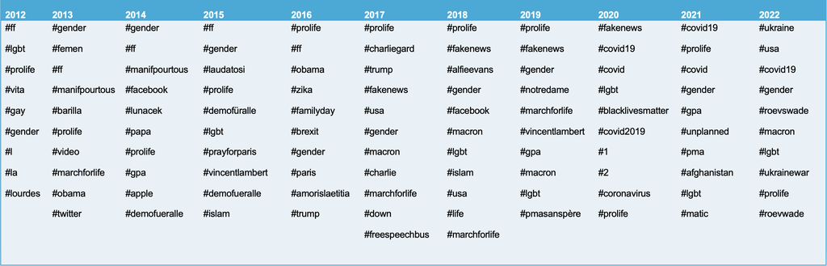

## Gender in focus (Tronina 2026)

Most Transnationally Connective Hashtags Per Year

*Dissemination* - getting the word out

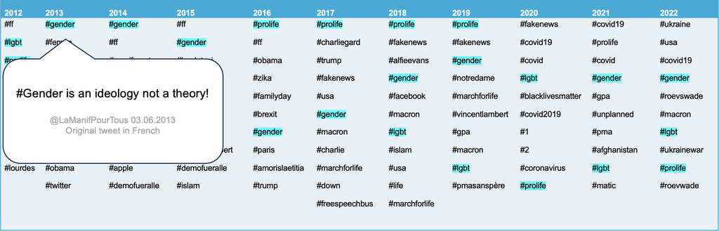

## Gender in focus (Tronina 2026)

Most Transnationally Connective Hashtags Per Year

*Dissemination* - getting the word out

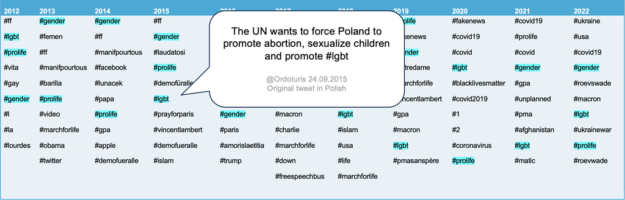

## Gender in focus (Tronina 2026)

Most Transnationally Connective Hashtags Per Year

*Mobilisation*

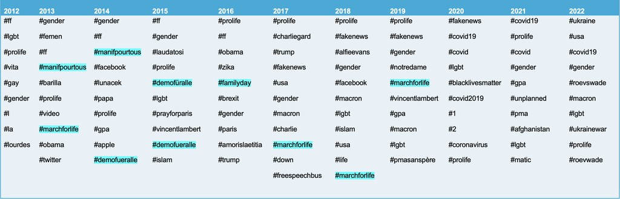

## Gender in focus (Tronina 2026)

Most Transnationally Connective Hashtags Per Year

*Extension* - connecting to other issues

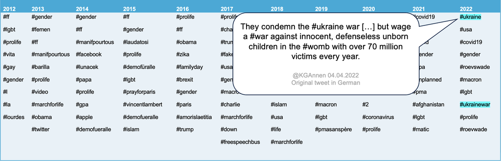

## RWE news ecology (Heft et al. 2021)

- ‘alternative news’ sites/channels spread RWE *discourses*
- Heft et al. (2021) look at hyperlinks shared by right-wing online news sites (in Austria, Germany, United States, United Kingdom, Denmark, Sweden) in 2018

## RWE news ecology (Heft et al. 2021)

- ‘alternative news’ sites/channels spread RWE *discourses*

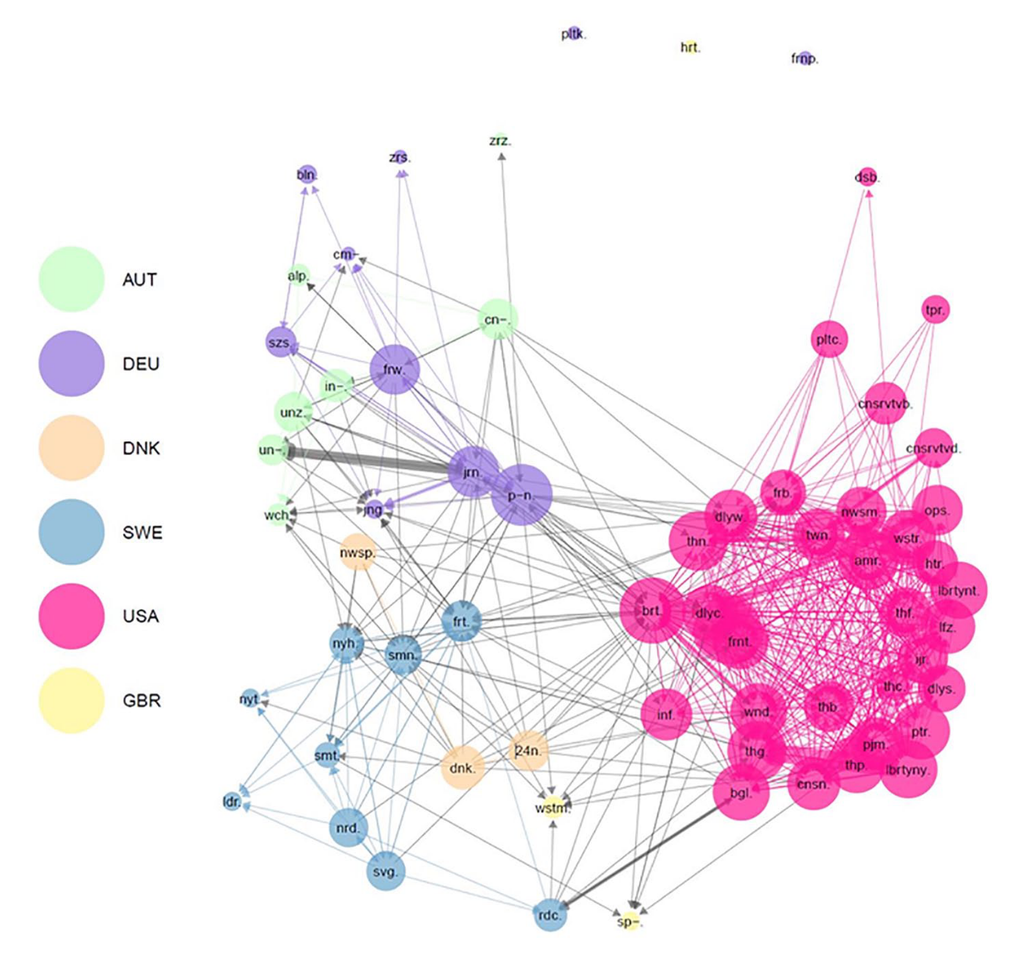

- degree of transnational linkages differ by context
- DE: some orgs. focus mostly domestically; others mostly internationally
- SE, US: most orgs., mostly **domestically**
- UK, AT, DK: most orgs., mostly **internationally**

## RWE protest mottos (DE)

*discourses* connect to *offline activity*: slogans of German RWE protests, some (randomly selected) examples:

**„Familien schützen! Homo-Propaganda stoppen!“**

*“Protect families! Stop gay propaganda!”*

**Thüringer Heldengedenken**

*Thuringian heroic commemoration*

**„Genug ist genug! Stoppt die Überfremdung der Heimat“ (Berlin)**

*“Enough is enough! Stop the foreign infiltration of the homeland” (Berlin)*

**Für Meinungsfreiheit – gegen staatliche Zensur**

*For freedom of expression – against state censorship*

**Nationale Souveränität erhalten – Deutschland raus aus der EU**

*Maintain national sovereignty – Germany out of the EU*

**„Mein Körper gehört mir, schützt endlich unsere Kinder und Alten“**

*“My body belongs to me, finally protects our children and the elderly”*

## RWE protest mottos (DE)

discourses connect to offline activity, here: the most frequent words in German RWE protest slogans

**all terms**

[interactive chart not shown]

## RWE protest mottos (DE)

discourses connect to offline activity, here: the most frequent words in German RWE protest slogans

**National identity**

[interactive chart not shown]

## RWE protest mottos (DE)

discourses connect to offline activity, here: the most frequent words in German RWE protest slogans

**Aspirations and community**

[interactive chart not shown]

## RWE protest mottos (DE)

discourses connect to offline activity, here: the most frequent words in German RWE protest slogans

**Anti-migration**

[interactive chart not shown]

## RWE protest mottos (DE)

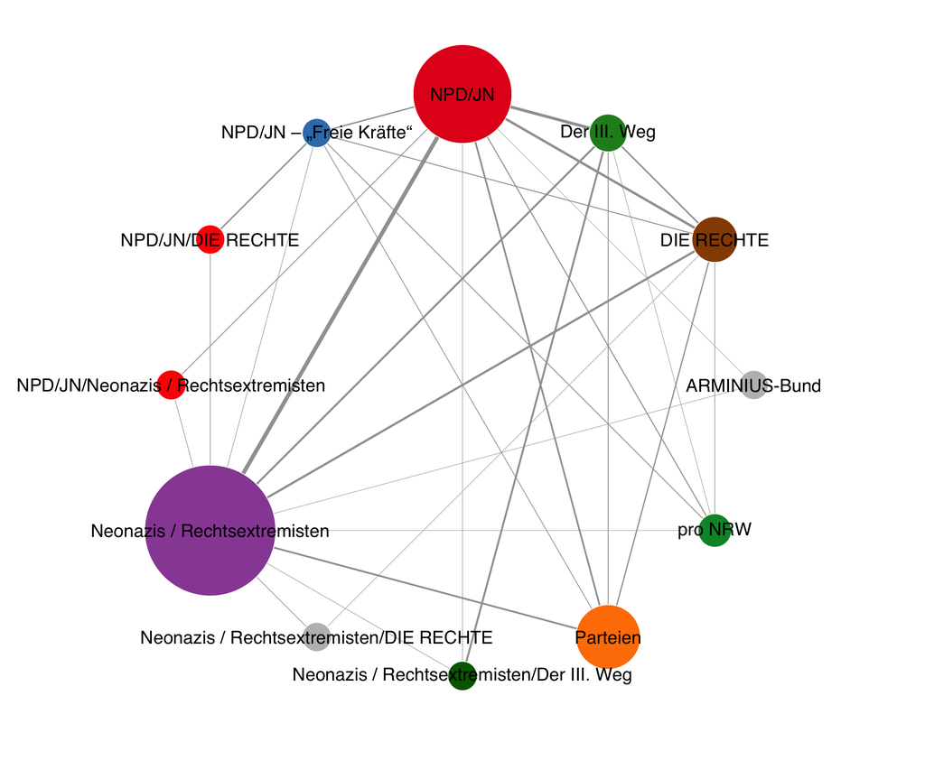

- nodes: RWE demonstration categories as tracked by German governments
- edges: indicate strength of similarity of terms in demo. groups’ ‘motto’ texts

# RWE Protest

- demonstrations serve many purposes for RWE: building *solidarity/collective identity* (Virchow 2007; Meadowcroft and Morrow 2017), attracting *media attention* (Castelli Gattinara and Froio 2024), recurrent dates for *networking* (Zeller 2026), *agenda setting* and building momentum for far-right parties (Weisskircher and Berntzen 2019)
- *countermobilisation* often emerges to oppose RWE protest—with mixed results (Vüllers and Hellmeier 2022; Rocchetti and Pilati 2025; Zeller 2022, 2025)
- several projects track RWE protest activity
  - some comparative: [Poldem](https://poldem.eui.eu/); [ACLED](https://acleddata.com/); myriad country-specific projects

## RWE Protest - overview

[interactive chart not shown]

[PolDem](https://poldem.eui.eu/) - xenophobic protests 2000-2015

## RWE Protest - overview

[interactive chart not shown]

[PolDem](https://poldem.eui.eu/) - xeno. protests 2000-2015, party participation

## RWE Protest - overview

[interactive chart not shown]

[PolDem](https://poldem.eui.eu/) - xenophobic protests 2000-2015

## RWE protest (Germany, Italy, UK)

**Italy**  
**UK**  
**Germany**

[interactive chart not shown]

## RWE protest (Germany, 2005-2024)

[interactive chart not shown]

responses to inquiries in Bundestag, e.g.: [first half 2026](https://dip.bundestag.de/vorgang/rechtsextreme-aufm%C3%A4rsche-im-ersten-halbjahr-2026/337069)

## RWE protest (Italy, 2008-2018)

[interactive chart not shown]

Gattinara’s Far-Right Protest Observatory: https://farpo.eu/dataset/expanded-cfp-dataset/

## RWE protest (UK, 2009-2019)

[interactive chart not shown]

Dafnos’s FRGB data: https://etheses.whiterose.ac.uk/id/eprint/28775/

# RWE Violence

- multiple *causes/contributions* of RWE violence (Koopmans 1996; Ravndal 2018; Whittington and Piatkowska 2024)
  - including RWE protest activity $\rightarrow$ driving violence rates (Jost et al. 2025)
- State responses against RWE violence sometimes *less intensive than other political violence* (Da Silva et al. 2022)
- RWE orgs. sometimes strategically *disavow violence* while *condoning RWE attackers* (Bjørgo and Ravndal 2020)
- RWE violence can *affect support* for *far-right parties* (De Juan, Haass, and Voß 2025; Krause and Matsunaga 2023)

## RWE Violence - hate crimes

[interactive chart not shown]

[OSCE](https://hatecrime.osce.org/incidents) hate crime monitoring

## RWE Violence - hate crimes

[interactive chart not shown]

[OSCE](https://hatecrime.osce.org/incidents) hate crime monitoring

## RWE Violence - hate crimes

[interactive chart not shown]

[OSCE](https://hatecrime.osce.org/incidents) hate crime monitoring

## RWE Violence - killings

[interactive chart not shown]

[RTV](https://www.sv.uio.no/c-rex/english/resources/rtv-dataset/) dataset of RWE violence in Western Europe

## RWE Violence - killings

[figure not shown]

## RWE homicides in Germany

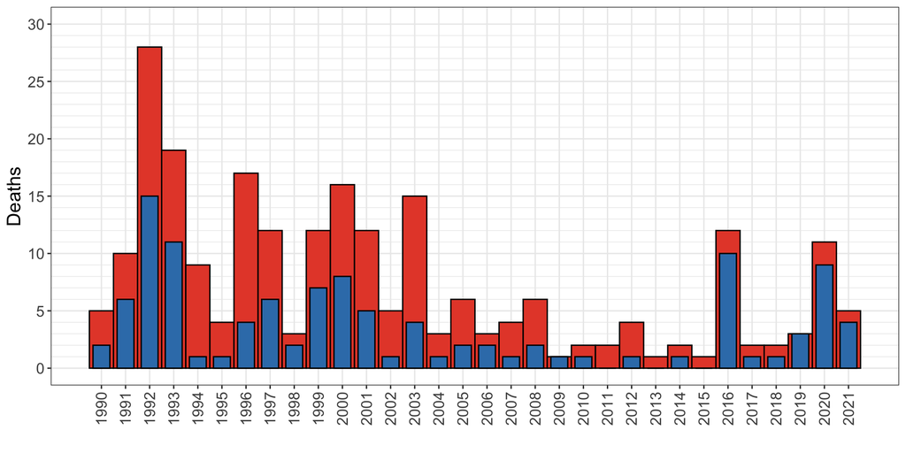

Recognised by BRD vs. identified by [Amadeu Antonio Stiftung](https://www.amadeu-antonio-stiftung.de/todesopfer-rechter-gewalt/)

## RWE homicides in Germany

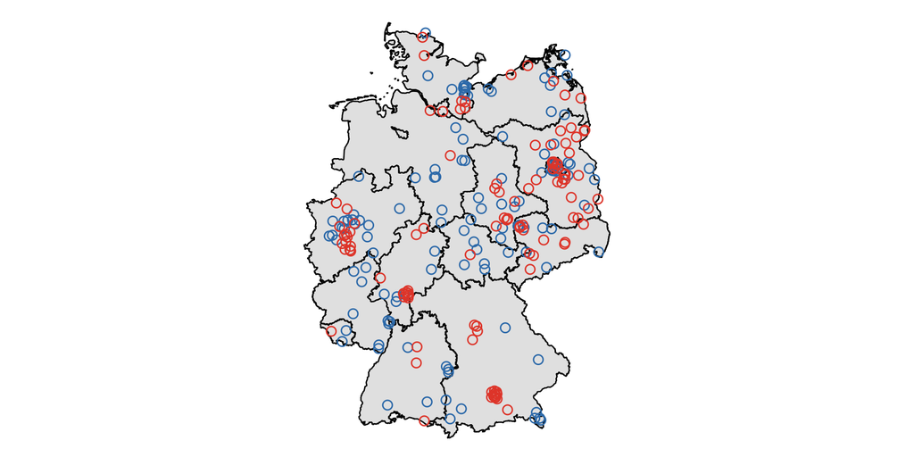

o: officially recognised by BRD  
o: identified by Amadeu Antonio Stiftung  
Recognised by BRD vs. identified by [Amadeu Antonio Stiftung](https://www.amadeu-antonio-stiftung.de/todesopfer-rechter-gewalt/)

# Problems of RWE in the round

## Problems of RWE in the round

- monitoring
  - constantly shifting standards of what qualifies as RWE
    - over time, in different contexts, by different actors
  - continued adaptive evasion by RWE actors (encrypted messengers, crypto currencies, dark web)
- responses
  - hindrance transnational cooperation: a national, not a *trans*national problem?
  - blockage by far-right party actors
  - **nevertheless**, steps taken at supranational levels (EU, hash-sharing database, Christchurch Call)

## References

Ahmed, Reem, and Daniela Pisoiu. 2021. “Uniting the Far Right: How the Far-Right Extremist, New Right, and Populist Frames Overlap on Twitter – a German Case Study.” *European Societies* 23 (2): 232–54. https://doi.org/10.1080/14616696.2020.1818112.

Bailard, Catie Snow, Rebekah Tromble, Wei Zhong, Federico Bianchi, Pedram Hosseini, and David Broniatowski. 2024. “‘Keep Your Heads Held High Boys!’: Examining the Relationship Between the Proud Boys’ Online Discourse and Offline Activities.” *American Political Science Review* 118 (4): 2054–71. https://doi.org/10.1017/S0003055423001478.

Bjørgo, Tore, and Jacob Aasland Ravndal. 2020. “Why the Nordic Resistance Movement Restrains Its Use of Violence.” *Perspectives on Terrorism* 14 (6): 37–48.

Castelli Gattinara, Pietro, and Caterina Froio. 2024. “When the Far Right Makes the News: Protest Characteristics and Media Coverage of Far-Right Mobilization in Europe.” *Comparative Political Studies* 57 (3): 419–52. https://doi.org/10.1177/00104140231169029.

Da Silva, Raquel, João Paulo Ventura, Cátia Moreira De Carvalho, and Mariana Reis Barbosa. 2022. “‘From Street Soldiers to Political Soldiers’: Assessing How Extreme Right Violence Has Been Criminalised in Portugal.” *Critical Studies on Terrorism* 15 (1): 102–20. https://doi.org/10.1080/17539153.2022.2031134.

De Juan, Alexander, Felix Haass, and Julian Voß. 2025. “Right-Wing Terror, Media Backlash, and Voting Preferences for the Far Right.” *British Journal of Political Science* 55: e130. https://doi.org/10.1017/S000712342510077X.

Giugni, Marco, Ruud Koopmans, Florence Passy, and Paul Statham. 2005. “[Institutional and Discursive Opportunities for Extreme-Right Mobilization in Five Countries](https://www.ncbi.nlm.nih.gov/pubmed/16602133).” *Mobilization: An International Quarterly* 10 (1): 145–62.

Heft, Annett, Curd Knüpfer, Susanne Reinhardt, and Eva Mayerhöffer. 2021. “Toward a Transnational Information Ecology on the Right? Hyperlink Networking Among Right-Wing Digital News Sites in Europe and the United States.” *The International Journal of Press/Politics* 26 (2): 484–504. https://doi.org/10.1177/1940161220963670.

Johnson, N. F., R. Leahy, N. Johnson Restrepo, N. Velasquez, M. Zheng, P. Manrique, P. Devkota, and S. Wuchty. 2019. “Hidden Resilience and Adaptive Dynamics of the Global Online Hate Ecology.” *Nature* 573 (7773): 261–65. https://doi.org/10.1038/s41586-019-1494-7.

Jost, Pablo, Mirko Allwinn, Hendrik Bitzmann, David Bretschi, Simon Greipl, Julian Hohner, Heidi Schulze, Harald Sick, and Diana Rieger. 2025. “Virtual Torches, Real Fires? Online Protest Mobilization as a Forward Indicator of Politically Motivated Crime.”

Kasimov, Andrey. 2023. “Decentralized Hate: Sustained Connective Action in Online Far-Right Community.” *Social Movement Studies*, April, 1–19. https://doi.org/10.1080/14742837.2023.2204427.

Koopmans, Ruud. 1996. “Explaining the Rise of Racist and Extreme Right Violence in Western Europe: Grievances or Opportunities?” *European Journal of Political Research* 30 (2): 185–216. https://doi.org/10.1111/j.1475-6765.1996.tb00674.x.

Krause, Werner, and Miku Matsunaga. 2023. “Does Right-Wing Violence Affect Public Support for Radical Right Parties? Evidence from Germany.” *Comparative Political Studies*, June, 001041402311690. https://doi.org/10.1177/00104140231169021.

Meadowcroft, John, and Elizabeth A Morrow. 2017. “Violence, Self-Worth, Solidarity and Stigma: How a Dissident, Far-Right Group Solves the Collective Action Problem.” *Political Studies* 65 (2): 373–90. https://doi.org/10.1177/0032321716651654.

Ravndal, Jacob Aasland. 2018. “Explaining Right-Wing Terrorism and Violence in Western Europe: Grievances, Opportunities and Polarisation.” *European Journal of Political Research* 57 (4): 845–66. https://doi.org/10.1111/1475-6765.12254.

Rocchetti, Davide, and Katia Pilati. 2025. “Dynamics of Protests and Counterprotests Around Far-Right Politics.” *American Behavioral Scientist*, 1–23.

Tronina, Dominika. 2026. “Transnationalization of Anti-Gender Politics on Social Media: Hashtag Practices and Cross-Border Visibility.” *Media and Communication* 14.

Vicenová, Radka. 2020. “The Role of Digital Media in the Strategies of Far-Right Vigilante Groups in Slovakia.” *Global Crime* 21 (3-4): 242–61. https://doi.org/10.1080/17440572.2019.1709171.

Virchow, Fabian. 2007. “Performance, Emotion, and Ideology: On the Creation of "Collectives of Emotion" and Worldview in the Contemporary German Far Right.” *Journal of Contemporary Ethnography* 36 (2): 147–64. https://doi.org/10.1177/0891241606298822.

Völker, Teresa, and Daniel Saldivia Gonzatti. 2024. “Discourse Networks of the Far Right: How Far-Right Actors Become Mainstream in Public Debates.” *Political Communication* 41 (3): 353–72. https://doi.org/10.1080/10584609.2024.2308601.

Vüllers, Johannes, and Sebastian Hellmeier. 2022. “Does Counter-Mobilization Contain Right-Wing Populist Movements? Evidence from Germany.” *European Journal of Political Research* 61 (1): 21–45. https://doi.org/10.1111/1475-6765.12439.

Weisskircher, Manès, and Lars Erik Berntzen. 2019. “Remaining on the Streets. Anti-Islamic PEGIDA Mobilization and Its Relationship to Far-right Party Politics.” In *Radical Right ’Movement Parties’ in Europe*, edited by Manuela Caiani and Ondrej Cisar. Abingdon: Routledge.

Whittington, Whitney, and Sylwia J Piatkowska. 2024. “Far-Right Extremism, Elections and Hate Crime: A Temporal Evaluation of Bias-Motivated Violence in Slovakia.” *The British Journal of Criminology*, June, 1–21. https://doi.org/10.1093/bjc/azae032.

Zeller, Michael C. 2022. “Demobilising Far-Right Demonstration Campaigns: Coercive Counter-Mobilisation, State Social Control, and the Demobilisation of the Hess Gedenkmarsch Campaign.” *Social Movement Studies* 21 (3): 372–90. https://doi.org/10.1080/14742837.2021.1889493.

———. 2025. “Pragmatic Rather Than Principled: Organisational Bans in Democracies.” *European Journal of Political Research* 65 (1): 650–73. https://doi.org/10.1017/S1475676525100121y.

———. 2026. *Demobilising the Far Right: Patterns and Processes from Demonstration Campaigns in Germany, England, and Austria*. Cambridge: Cambridge University Press.